# CAPTION PROJECT ON CUSTOMER CHURN DATA SET

```python
import numpy as np
import pandas as pd
```

```python
data=pd.read_csv("customer_churn.csv")
```

```python
data
```

|  | customerID | gender | SeniorCitizen | Partner | Dependents | tenure | PhoneService | MultipleLines | InternetService | OnlineSecurity | ... | DeviceProtection | TechSupport | StreamingTV | StreamingMovies | Contract | PaperlessBilling | PaymentMethod | MonthlyCharges | TotalCharges | Churn |
| --- | --- | --- | --- | --- | --- | --- | --- | --- | --- | --- | --- | --- | --- | --- | --- | --- | --- | --- | --- | --- | --- |
| 0 | 7590-VHVEG | Female | 0 | Yes | No | 1 | No | No phone service | DSL | No | ... | No | No | No | No | Month-to-month | Yes | Electronic check | 29.85 | 29.85 | No |
| 1 | 5575-GNVDE | Male | 0 | No | No | 34 | Yes | No | DSL | Yes | ... | Yes | No | No | No | One year | No | Mailed check | 56.95 | 1889.5 | No |
| 2 | 3668-QPYBK | Male | 0 | No | No | 2 | Yes | No | DSL | Yes | ... | No | No | No | No | Month-to-month | Yes | Mailed check | 53.85 | 108.15 | Yes |
| 3 | 7795-CFOCW | Male | 0 | No | No | 45 | No | No phone service | DSL | Yes | ... | Yes | Yes | No | No | One year | No | Bank transfer (automatic) | 42.30 | 1840.75 | No |
| 4 | 9237-HQITU | Female | 0 | No | No | 2 | Yes | No | Fiber optic | No | ... | No | No | No | No | Month-to-month | Yes | Electronic check | 70.70 | 151.65 | Yes |
| ... | ... | ... | ... | ... | ... | ... | ... | ... | ... | ... | ... | ... | ... | ... | ... | ... | ... | ... | ... | ... | ... |
| 7038 | 6840-RESVB | Male | 0 | Yes | Yes | 24 | Yes | Yes | DSL | Yes | ... | Yes | Yes | Yes | Yes | One year | Yes | Mailed check | 84.80 | 1990.5 | No |
| 7039 | 2234-XADUH | Female | 0 | Yes | Yes | 72 | Yes | Yes | Fiber optic | No | ... | Yes | No | Yes | Yes | One year | Yes | Credit card (automatic) | 103.20 | 7362.9 | No |
| 7040 | 4801-JZAZL | Female | 0 | Yes | Yes | 11 | No | No phone service | DSL | Yes | ... | No | No | No | No | Month-to-month | Yes | Electronic check | 29.60 | 346.45 | No |
| 7041 | 8361-LTMKD | Male | 1 | Yes | No | 4 | Yes | Yes | Fiber optic | No | ... | No | No | No | No | Month-to-month | Yes | Mailed check | 74.40 | 306.6 | Yes |
| 7042 | 3186-AJIEK | Male | 0 | No | No | 66 | Yes | No | Fiber optic | Yes | ... | Yes | Yes | Yes | Yes | Two year | Yes | Bank transfer (automatic) | 105.65 | 6844.5 | No |

7043 rows × 21 columns

```python
data.head()
```

|  | customerID | gender | SeniorCitizen | Partner | Dependents | tenure | PhoneService | MultipleLines | InternetService | OnlineSecurity | ... | DeviceProtection | TechSupport | StreamingTV | StreamingMovies | Contract | PaperlessBilling | PaymentMethod | MonthlyCharges | TotalCharges | Churn |
| --- | --- | --- | --- | --- | --- | --- | --- | --- | --- | --- | --- | --- | --- | --- | --- | --- | --- | --- | --- | --- | --- |
| 0 | 7590-VHVEG | Female | 0 | Yes | No | 1 | No | No phone service | DSL | No | ... | No | No | No | No | Month-to-month | Yes | Electronic check | 29.85 | 29.85 | No |
| 1 | 5575-GNVDE | Male | 0 | No | No | 34 | Yes | No | DSL | Yes | ... | Yes | No | No | No | One year | No | Mailed check | 56.95 | 1889.5 | No |
| 2 | 3668-QPYBK | Male | 0 | No | No | 2 | Yes | No | DSL | Yes | ... | No | No | No | No | Month-to-month | Yes | Mailed check | 53.85 | 108.15 | Yes |
| 3 | 7795-CFOCW | Male | 0 | No | No | 45 | No | No phone service | DSL | Yes | ... | Yes | Yes | No | No | One year | No | Bank transfer (automatic) | 42.30 | 1840.75 | No |
| 4 | 9237-HQITU | Female | 0 | No | No | 2 | Yes | No | Fiber optic | No | ... | No | No | No | No | Month-to-month | Yes | Electronic check | 70.70 | 151.65 | Yes |

5 rows × 21 columns

# A)Data Manipulation

### a) Extract the 5th column and store it in 'customer_5'

```python
customer_5=data.iloc[:,4]
customer_5
```

```
0        No
1        No
2        No
3        No
4        No
       ...
7038    Yes
7039    Yes
7040    Yes
7041     No
7042     No
Name: Dependents, Length: 7043, dtype: object
```

### b)extract the 15th column and store it in 'customer_15'

```python
customer_15=data.iloc[:,14]
customer_15
```

```
0        No
1        No
2        No
3        No
4        No
       ...
7038    Yes
7039    Yes
7040     No
7041     No
7042    Yes
Name: StreamingMovies, Length: 7043, dtype: object
```

```python
data.head(2)
```

|  | customerID | gender | SeniorCitizen | Partner | Dependents | tenure | PhoneService | MultipleLines | InternetService | OnlineSecurity | ... | DeviceProtection | TechSupport | StreamingTV | StreamingMovies | Contract | PaperlessBilling | PaymentMethod | MonthlyCharges | TotalCharges | Churn |
| --- | --- | --- | --- | --- | --- | --- | --- | --- | --- | --- | --- | --- | --- | --- | --- | --- | --- | --- | --- | --- | --- |
| 0 | 7590-VHVEG | Female | 0 | Yes | No | 1 | No | No phone service | DSL | No | ... | No | No | No | No | Month-to-month | Yes | Electronic check | 29.85 | 29.85 | No |
| 1 | 5575-GNVDE | Male | 0 | No | No | 34 | Yes | No | DSL | Yes | ... | Yes | No | No | No | One year | No | Mailed check | 56.95 | 1889.5 | No |

2 rows × 21 columns

## C)Extract all the male senior citizen whose payment method is electronic check and store the result in 'senior_male_electronic'

```python
senior_male_electronic=data[(data['gender']=='Male') & (data['SeniorCitizen']==1) & (data['PaymentMethod']=='Electronic check')]
```

```python
senior_male_electronic
```

|  | customerID | gender | SeniorCitizen | Partner | Dependents | tenure | PhoneService | MultipleLines | InternetService | OnlineSecurity | ... | DeviceProtection | TechSupport | StreamingTV | StreamingMovies | Contract | PaperlessBilling | PaymentMethod | MonthlyCharges | TotalCharges | Churn |
| --- | --- | --- | --- | --- | --- | --- | --- | --- | --- | --- | --- | --- | --- | --- | --- | --- | --- | --- | --- | --- | --- |
| 20 | 8779-QRDMV | Male | 1 | No | No | 1 | No | No phone service | DSL | No | ... | Yes | No | No | Yes | Month-to-month | Yes | Electronic check | 39.65 | 39.65 | Yes |
| 55 | 1658-BYGOY | Male | 1 | No | No | 18 | Yes | Yes | Fiber optic | No | ... | No | No | Yes | Yes | Month-to-month | Yes | Electronic check | 95.45 | 1752.55 | Yes |
| 57 | 5067-XJQFU | Male | 1 | Yes | Yes | 66 | Yes | Yes | Fiber optic | No | ... | Yes | Yes | Yes | Yes | One year | Yes | Electronic check | 108.45 | 7076.35 | No |
| 78 | 0191-ZHSKZ | Male | 1 | No | No | 30 | Yes | No | DSL | Yes | ... | No | No | Yes | Yes | Month-to-month | Yes | Electronic check | 74.75 | 2111.3 | No |
| 91 | 2424-WVHPL | Male | 1 | No | No | 1 | Yes | No | Fiber optic | No | ... | No | Yes | No | No | Month-to-month | No | Electronic check | 74.70 | 74.7 | No |
| ... | ... | ... | ... | ... | ... | ... | ... | ... | ... | ... | ... | ... | ... | ... | ... | ... | ... | ... | ... | ... | ... |
| 6837 | 6229-LSCKB | Male | 1 | No | No | 6 | Yes | No | Fiber optic | No | ... | No | No | Yes | No | Month-to-month | Yes | Electronic check | 79.70 | 497.6 | No |
| 6894 | 1400-MMYXY | Male | 1 | Yes | No | 3 | Yes | Yes | Fiber optic | No | ... | Yes | No | Yes | Yes | Month-to-month | Yes | Electronic check | 105.90 | 334.65 | Yes |
| 6914 | 7142-HVGBG | Male | 1 | Yes | No | 43 | Yes | Yes | Fiber optic | No | ... | Yes | No | Yes | Yes | Month-to-month | Yes | Electronic check | 103.00 | 4414.3 | Yes |
| 6967 | 8739-WWKDU | Male | 1 | No | No | 25 | Yes | Yes | Fiber optic | No | ... | No | No | Yes | No | Month-to-month | Yes | Electronic check | 89.50 | 2196.15 | Yes |
| 7032 | 6894-LFHLY | Male | 1 | No | No | 1 | Yes | Yes | Fiber optic | No | ... | No | No | No | No | Month-to-month | Yes | Electronic check | 75.75 | 75.75 | Yes |

298 rows × 21 columns

## D)Extract all those customers whose tenure is greater than 70 months or their Monthly charges is more than 100 & store the result in 'customer_total_tenure'

```python
data.head(2)
```

|  | customerID | gender | SeniorCitizen | Partner | Dependents | tenure | PhoneService | MultipleLines | InternetService | OnlineSecurity | ... | DeviceProtection | TechSupport | StreamingTV | StreamingMovies | Contract | PaperlessBilling | PaymentMethod | MonthlyCharges | TotalCharges | Churn |
| --- | --- | --- | --- | --- | --- | --- | --- | --- | --- | --- | --- | --- | --- | --- | --- | --- | --- | --- | --- | --- | --- |
| 0 | 7590-VHVEG | Female | 0 | Yes | No | 1 | No | No phone service | DSL | No | ... | No | No | No | No | Month-to-month | Yes | Electronic check | 29.85 | 29.85 | No |
| 1 | 5575-GNVDE | Male | 0 | No | No | 34 | Yes | No | DSL | Yes | ... | Yes | No | No | No | One year | No | Mailed check | 56.95 | 1889.5 | No |

2 rows × 21 columns

```python
customer_total_tenure=data[(data['tenure']>70) | (data['MonthlyCharges'] >100)]
```

```python
customer_total_tenure
```

|  | customerID | gender | SeniorCitizen | Partner | Dependents | tenure | PhoneService | MultipleLines | InternetService | OnlineSecurity | ... | DeviceProtection | TechSupport | StreamingTV | StreamingMovies | Contract | PaperlessBilling | PaymentMethod | MonthlyCharges | TotalCharges | Churn |
| --- | --- | --- | --- | --- | --- | --- | --- | --- | --- | --- | --- | --- | --- | --- | --- | --- | --- | --- | --- | --- | --- |
| 8 | 7892-POOKP | Female | 0 | Yes | No | 28 | Yes | Yes | Fiber optic | No | ... | Yes | Yes | Yes | Yes | Month-to-month | Yes | Electronic check | 104.80 | 3046.05 | Yes |
| 12 | 8091-TTVAX | Male | 0 | Yes | No | 58 | Yes | Yes | Fiber optic | No | ... | Yes | No | Yes | Yes | One year | No | Credit card (automatic) | 100.35 | 5681.1 | No |
| 13 | 0280-XJGEX | Male | 0 | No | No | 49 | Yes | Yes | Fiber optic | No | ... | Yes | No | Yes | Yes | Month-to-month | Yes | Bank transfer (automatic) | 103.70 | 5036.3 | Yes |
| 14 | 5129-JLPIS | Male | 0 | No | No | 25 | Yes | No | Fiber optic | Yes | ... | Yes | Yes | Yes | Yes | Month-to-month | Yes | Electronic check | 105.50 | 2686.05 | No |
| 15 | 3655-SNQYZ | Female | 0 | Yes | Yes | 69 | Yes | Yes | Fiber optic | Yes | ... | Yes | Yes | Yes | Yes | Two year | No | Credit card (automatic) | 113.25 | 7895.15 | No |
| ... | ... | ... | ... | ... | ... | ... | ... | ... | ... | ... | ... | ... | ... | ... | ... | ... | ... | ... | ... | ... | ... |
| 7023 | 1035-IPQPU | Female | 1 | Yes | No | 63 | Yes | Yes | Fiber optic | No | ... | Yes | No | Yes | Yes | Month-to-month | Yes | Electronic check | 103.50 | 6479.4 | No |
| 7034 | 0639-TSIQW | Female | 0 | No | No | 67 | Yes | Yes | Fiber optic | Yes | ... | Yes | No | Yes | No | Month-to-month | Yes | Credit card (automatic) | 102.95 | 6886.25 | Yes |
| 7037 | 2569-WGERO | Female | 0 | No | No | 72 | Yes | No | No | No internet service | ... | No internet service | No internet service | No internet service | No internet service | Two year | Yes | Bank transfer (automatic) | 21.15 | 1419.4 | No |
| 7039 | 2234-XADUH | Female | 0 | Yes | Yes | 72 | Yes | Yes | Fiber optic | No | ... | Yes | No | Yes | Yes | One year | Yes | Credit card (automatic) | 103.20 | 7362.9 | No |
| 7042 | 3186-AJIEK | Male | 0 | No | No | 66 | Yes | No | Fiber optic | Yes | ... | Yes | Yes | Yes | Yes | Two year | Yes | Bank transfer (automatic) | 105.65 | 6844.5 | No |

1259 rows × 21 columns

## E)Extract all the customers whose contract is of two years,payment method is mailed check & the value of churn is 'yes' & store the result in'two_mail_yes'

```python
data.head(2)
```

|  | customerID | gender | SeniorCitizen | Partner | Dependents | tenure | PhoneService | MultipleLines | InternetService | OnlineSecurity | ... | DeviceProtection | TechSupport | StreamingTV | StreamingMovies | Contract | PaperlessBilling | PaymentMethod | MonthlyCharges | TotalCharges | Churn |
| --- | --- | --- | --- | --- | --- | --- | --- | --- | --- | --- | --- | --- | --- | --- | --- | --- | --- | --- | --- | --- | --- |
| 0 | 7590-VHVEG | Female | 0 | Yes | No | 1 | No | No phone service | DSL | No | ... | No | No | No | No | Month-to-month | Yes | Electronic check | 29.85 | 29.85 | No |
| 1 | 5575-GNVDE | Male | 0 | No | No | 34 | Yes | No | DSL | Yes | ... | Yes | No | No | No | One year | No | Mailed check | 56.95 | 1889.5 | No |

2 rows × 21 columns

```python
two_mail_yes=data[(data['Contract']=='Two year') & (data['PaymentMethod']=='Mailed check') & (data['Churn']=='Yes')]
```

```python
two_mail_yes
```

|  | customerID | gender | SeniorCitizen | Partner | Dependents | tenure | PhoneService | MultipleLines | InternetService | OnlineSecurity | ... | DeviceProtection | TechSupport | StreamingTV | StreamingMovies | Contract | PaperlessBilling | PaymentMethod | MonthlyCharges | TotalCharges | Churn |
| --- | --- | --- | --- | --- | --- | --- | --- | --- | --- | --- | --- | --- | --- | --- | --- | --- | --- | --- | --- | --- | --- |
| 268 | 6323-AYBRX | Male | 0 | No | No | 59 | Yes | No | No | No internet service | ... | No internet service | No internet service | No internet service | No internet service | Two year | No | Mailed check | 19.35 | 1099.6 | Yes |
| 5947 | 7951-QKZPL | Female | 0 | Yes | Yes | 33 | Yes | Yes | No | No internet service | ... | No internet service | No internet service | No internet service | No internet service | Two year | Yes | Mailed check | 24.50 | 740.3 | Yes |
| 6680 | 9412-ARGBX | Female | 0 | No | Yes | 48 | Yes | No | Fiber optic | No | ... | Yes | Yes | Yes | No | Two year | Yes | Mailed check | 95.50 | 4627.85 | Yes |

3 rows × 21 columns

## F)Extract 333 random records from the customer_churn dataframe & store the result in 'customer_333'

```python
customer_333=data.sample(n=333)
```

```python
customer_333
```

|  | customerID | gender | SeniorCitizen | Partner | Dependents | tenure | PhoneService | MultipleLines | InternetService | OnlineSecurity | ... | DeviceProtection | TechSupport | StreamingTV | StreamingMovies | Contract | PaperlessBilling | PaymentMethod | MonthlyCharges | TotalCharges | Churn |
| --- | --- | --- | --- | --- | --- | --- | --- | --- | --- | --- | --- | --- | --- | --- | --- | --- | --- | --- | --- | --- | --- |
| 1589 | 7351-KYHQH | Female | 1 | No | No | 7 | Yes | No | DSL | No | ... | Yes | No | Yes | No | Month-to-month | Yes | Electronic check | 64.95 | 493.65 | No |
| 382 | 8204-YJCLA | Male | 1 | Yes | Yes | 72 | No | No phone service | DSL | Yes | ... | Yes | Yes | Yes | Yes | Two year | Yes | Bank transfer (automatic) | 64.80 | 4732.35 | No |
| 1480 | 8898-KASCD | Male | 0 | No | No | 39 | No | No phone service | DSL | No | ... | Yes | Yes | No | No | One year | No | Mailed check | 35.55 | 1309.15 | No |
| 5645 | 4942-VZZOM | Male | 0 | Yes | No | 64 | Yes | Yes | DSL | Yes | ... | No | No | Yes | No | One year | Yes | Credit card (automatic) | 66.15 | 4392.5 | No |
| 5379 | 6284-KMNUF | Female | 0 | Yes | No | 56 | Yes | Yes | Fiber optic | Yes | ... | No | No | Yes | Yes | One year | Yes | Electronic check | 98.00 | 5270.6 | No |
| ... | ... | ... | ... | ... | ... | ... | ... | ... | ... | ... | ... | ... | ... | ... | ... | ... | ... | ... | ... | ... | ... |
| 106 | 6728-DKUCO | Female | 0 | Yes | Yes | 72 | Yes | Yes | Fiber optic | Yes | ... | No | No | Yes | Yes | One year | Yes | Electronic check | 104.15 | 7303.05 | No |
| 6521 | 1092-WPIVQ | Female | 0 | Yes | Yes | 18 | Yes | Yes | No | No internet service | ... | No internet service | No internet service | No internet service | No internet service | Two year | No | Mailed check | 25.10 | 428.45 | No |
| 4810 | 1112-CUNAO | Female | 1 | No | No | 15 | Yes | Yes | Fiber optic | No | ... | No | No | No | Yes | Month-to-month | No | Electronic check | 89.85 | 1424.95 | Yes |
| 4194 | 2961-VNFKL | Female | 0 | Yes | No | 71 | Yes | Yes | No | No internet service | ... | No internet service | No internet service | No internet service | No internet service | Two year | Yes | Credit card (automatic) | 25.95 | 1801.9 | No |
| 6317 | 7493-TPUWZ | Male | 0 | No | No | 1 | Yes | Yes | Fiber optic | No | ... | No | No | No | No | Month-to-month | Yes | Electronic check | 79.15 | 79.15 | Yes |

333 rows × 21 columns

## g) Get the count of different levels from the 'churn' column

```python
data['Churn'].value_counts()
```

```
No     5174
Yes    1869
Name: Churn, dtype: int64
```

# Data visualization

## A)Build a barplot for the 'InternetService' column

### i)set x-axis label to 'Categories of internet Service'

### ii)set y-axis label to 'Count of Categories'

### iii)set the title of plot to be 'Distribution of internet Service'

```python
data.head(2)
```

|  | customerID | gender | SeniorCitizen | Partner | Dependents | tenure | PhoneService | MultipleLines | InternetService | OnlineSecurity | ... | DeviceProtection | TechSupport | StreamingTV | StreamingMovies | Contract | PaperlessBilling | PaymentMethod | MonthlyCharges | TotalCharges | Churn |
| --- | --- | --- | --- | --- | --- | --- | --- | --- | --- | --- | --- | --- | --- | --- | --- | --- | --- | --- | --- | --- | --- |
| 0 | 7590-VHVEG | Female | 0 | Yes | No | 1 | No | No phone service | DSL | No | ... | No | No | No | No | Month-to-month | Yes | Electronic check | 29.85 | 29.85 | No |
| 1 | 5575-GNVDE | Male | 0 | No | No | 34 | Yes | No | DSL | Yes | ... | Yes | No | No | No | One year | No | Mailed check | 56.95 | 1889.5 | No |

2 rows × 21 columns

```python
import matplotlib.pyplot as plt
```

```python
data['InternetService'].value_counts()
```

```
Fiber optic    3096
DSL            2421
No             1526
Name: InternetService, dtype: int64
```

```python
x=data['InternetService'].value_counts().keys()
```

```python
x
```

```
Index(['Fiber optic', 'DSL', 'No'], dtype='object')
```

```python
y=data['InternetService'].value_counts().tolist()
y
```

```
[3096, 2421, 1526]
```

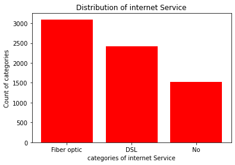

```python
import numpy as np
import matplotlib.pyplot as plt

plt.bar(x,y,color='red')
plt.xlabel("categories of internet Service")
plt.ylabel("Count of categories")
plt.title("Distribution of internet Service")
plt.show()
```

# b)Build a histogram for the 'tenure' column:

## i)set num of bins to be 30

## ii)set the color of bins to be 'green'

## iii)Assign the title 'Distribution of tenure'

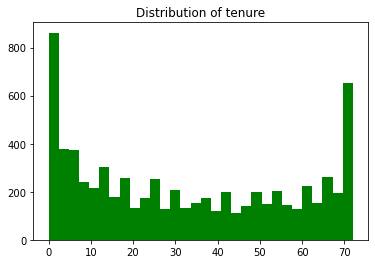

```python
plt.hist(data['tenure'],bins=30,color='green')
plt.title("Distribution of tenure")
plt.show()
```

### Built a scatter-plot between 'MonthlyCharges' & 'tenure'. Map 'MonthlyCharges' to the y-axis & 'tenure' to the 'x-axis'

#### i)Assign the points a color of 'brown'

#### ii)Set the x-axis label to tenure of customer

#### iii)Set the y-axis label to 'Monthly Charges of customer'

#### iV)Set the title to the 'Tenure vs Monthly Charges'

```python
import pandas as pd
```

```python
data=pd.read_csv("customer_churn.csv")
```

```python
data.head(2)
```

|  | customerID | gender | SeniorCitizen | Partner | Dependents | tenure | PhoneService | MultipleLines | InternetService | OnlineSecurity | ... | DeviceProtection | TechSupport | StreamingTV | StreamingMovies | Contract | PaperlessBilling | PaymentMethod | MonthlyCharges | TotalCharges | Churn |
| --- | --- | --- | --- | --- | --- | --- | --- | --- | --- | --- | --- | --- | --- | --- | --- | --- | --- | --- | --- | --- | --- |
| 0 | 7590-VHVEG | Female | 0 | Yes | No | 1 | No | No phone service | DSL | No | ... | No | No | No | No | Month-to-month | Yes | Electronic check | 29.85 | 29.85 | No |
| 1 | 5575-GNVDE | Male | 0 | No | No | 34 | Yes | No | DSL | Yes | ... | Yes | No | No | No | One year | No | Mailed check | 56.95 | 1889.5 | No |

2 rows × 21 columns

```python
import matplotlib.pyplot as plt
```

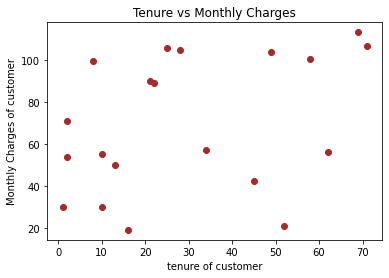

```python
plt.scatter(x=data['tenure'].head(20),y=data['MonthlyCharges'].head(20),color='brown')
plt.xlabel('tenure of customer')
plt.ylabel('Monthly Charges of customer')
plt.title('Tenure vs Monthly Charges')
plt.show()
```

## d)built a boxplot between tenure & contract. Map 'tenure' on y-axis and 'Contract' on the x-axis

```python
import seaborn as sns
```

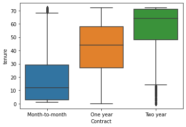

```python
sns.boxplot(x=data['Contract'],y=data['tenure'])
plt.show()
```

```python
import seaborn as sns
import matplotlib.pyplot as plt
```

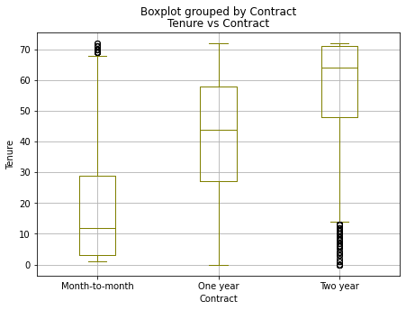

```python
data.boxplot(by=['Contract'],column="tenure",figsize=(7,5),color='olive')
plt.xlabel("Contract")
plt.ylabel("Tenure")
plt.title("Tenure vs Contract")
plt.show()
```

# Linear Regression

## A)Built a simple linear model where dependent variable is 'MonthlyCharges' and independent variable is 'tenure'

### i)Divide the dataset into train and test sets is 70:30 ratio

### ii)built the model on train set and predict the values on test set

### iii)After predicting the value find the root mean square error

### iv)Find out the error in prediction & store the result in 'error'

### v)find the root mean square error

```python
from sklearn.model_selection import train_test_split
```

```python
from sklearn.linear_model import LinearRegression
```

```python
data.head(2)
```

|  | customerID | gender | SeniorCitizen | Partner | Dependents | tenure | PhoneService | MultipleLines | InternetService | OnlineSecurity | ... | DeviceProtection | TechSupport | StreamingTV | StreamingMovies | Contract | PaperlessBilling | PaymentMethod | MonthlyCharges | TotalCharges | Churn |
| --- | --- | --- | --- | --- | --- | --- | --- | --- | --- | --- | --- | --- | --- | --- | --- | --- | --- | --- | --- | --- | --- |
| 0 | 7590-VHVEG | Female | 0 | Yes | No | 1 | No | No phone service | DSL | No | ... | No | No | No | No | Month-to-month | Yes | Electronic check | 29.85 | 29.85 | No |
| 1 | 5575-GNVDE | Male | 0 | No | No | 34 | Yes | No | DSL | Yes | ... | Yes | No | No | No | One year | No | Mailed check | 56.95 | 1889.5 | No |

2 rows × 21 columns

```python
x=pd.DataFrame(data['tenure']) #independent variable
```

```python
y=data['MonthlyCharges']       # dependent variable
```

```python
x_train,x_test,y_train,y_test=train_test_split(x,y,test_size=0.3,random_state=0)
```

```python
print(data.shape)
print(x_train.shape)
print(x_test.shape)
print(y_train.shape)
print(y_test.shape)
```

```
(7043, 21)
(4930, 1)
(2113, 1)
(4930,)
(2113,)
```

```python
import numpy as np
import pandas as pd
```

```python
data=pd.read_csv("customer_churn.csv")
```

```python
data.head(2)
```

|  | customerID | gender | SeniorCitizen | Partner | Dependents | tenure | PhoneService | MultipleLines | InternetService | OnlineSecurity | ... | DeviceProtection | TechSupport | StreamingTV | StreamingMovies | Contract | PaperlessBilling | PaymentMethod | MonthlyCharges | TotalCharges | Churn |
| --- | --- | --- | --- | --- | --- | --- | --- | --- | --- | --- | --- | --- | --- | --- | --- | --- | --- | --- | --- | --- | --- |
| 0 | 7590-VHVEG | Female | 0 | Yes | No | 1 | No | No phone service | DSL | No | ... | No | No | No | No | Month-to-month | Yes | Electronic check | 29.85 | 29.85 | No |
| 1 | 5575-GNVDE | Male | 0 | No | No | 34 | Yes | No | DSL | Yes | ... | Yes | No | No | No | One year | No | Mailed check | 56.95 | 1889.5 | No |

2 rows × 21 columns

```python
lr=LinearRegression()
```

```python
lr.fit(x_train,y_train)
```

```
LinearRegression()
```

```python
y_pred=lr.predict(x_test)
```

```python
y_pred
```

```
array([60.95089608, 72.98096699, 59.1903979 , ..., 75.62171426,
       70.63363608, 65.6455579 ])
```

```python
y_test.values
```

```
array([ 58.2 , 116.6 ,  71.95, ..., 109.95,  24.55,  81.6 ])
```

```python
from sklearn.metrics import mean_squared_error
import numpy as np
```

```python
msc=mean_squared_error(y_test,y_pred)
```

```python
error=np.sqrt(msc)
```

```python
error
```

```
29.394584027273893
```

# D)Logistic Regression

## a)Built a simple logistic regressin model where dependent variable is 'churn' & independent variable is 'MonthlyCharges'

### i)Divide the dataset into 65:35 ratio

### ii)Build the model on train set and predict the values on test set

### iV)Build the confusion matrix and get the accuracy score

```python
from sklearn.linear_model import LogisticRegression
```

```python
x=pd.DataFrame(data['MonthlyCharges'])
```

```python
y=data['Churn']
```

```python
x_train,x_test,y_train,y_test=train_test_split(x,y,train_size=0.65,random_state=0)
```

```python
logmodel=LogisticRegression()
```

```python
logmodel.fit(x_train,y_train)
```

```
LogisticRegression()
```

```python
y_pred=logmodel.predict(x_test)
```

```python
y_pred
```

```
array(['No', 'No', 'No', ..., 'No', 'No', 'No'], dtype=object)
```

```python
y_test.values
```

```
array(['No', 'No', 'No', ..., 'Yes', 'No', 'No'], dtype=object)
```

```python
from sklearn.metrics import confusion_matrix,accuracy_score
```

```python
confusion_matrix(y_pred,y_test)
```

```
array([[1815,  651],
       [   0,    0]])
```

```python
(1815+0)/(1815+651+0+0)
```

```
0.7360097323600974
```

```python
accuracy_score(y_pred,y_test)
```

```
0.7360097323600974
```

## b)Built a multiple logistic regression model where dependent variable is 'Churn' & independent variable are 'tenure' & 'MonthlyCharges'

### i)Divide the dataset in 80:20 ratio

### ii)Built the model on train set and predict the values on test set

### iii)Built the confusion matrix and get accuracy score

```python
x=pd.DataFrame(data.loc[:,['tenure','MonthlyCharges']])
```

```python
y=data['Churn']
```

```python
x_train,x_test,y_train,y_test=train_test_split(x,y,train_size=0.8,random_state=0)
```

```python
mlr=LogisticRegression()
```

```python
mlr.fit(x_train,y_train)
```

```
LogisticRegression()
```

```python
y_pred=mlr.predict(x_test)
```

```python
y_pred
```

```
array(['No', 'No', 'No', ..., 'No', 'No', 'No'], dtype=object)
```

```python
y_test.values
```

```
array(['No', 'No', 'No', ..., 'Yes', 'No', 'No'], dtype=object)
```

```python
from sklearn.metrics import confusion_matrix,accuracy_score
```

```python
print(confusion_matrix(y_pred,y_test))
```

```
[[934 212]
 [107 156]]
```

```python
(934+156)/(934+156+212+107)
```

```
0.7735982966643009
```

```python
accuracy_score(y_test,y_pred)
```

```
0.7735982966643009
```

### E) Decision Tree:

### a. Build a decision tree model where dependent variable is ‘Churn’ & independent variable is ‘tenure’

### i. Divide the dataset in 80:20 ratio

### ii. Build the model on train set and predict the values on test set

### iii. Build the confusion matrix and calculate the accuracy

```python
x=pd.DataFrame(data.loc[:,['tenure']])
y=data['Churn']
```

```python
x_train,x_test,y_train,y_test=train_test_split(x,y,train_size=0.8,random_state=0)
```

```python
from sklearn.tree import DecisionTreeClassifier
```

```python
# Create Decision Tree classifer object
clf = DecisionTreeClassifier()

# Train Decision Tree Classifer
clf = clf.fit(x_train,y_train)

#Predict the response for test dataset
y_pred = clf.predict(x_test)
```

```python
y_pred
```

```
array(['No', 'No', 'No', ..., 'No', 'No', 'Yes'], dtype=object)
```

```python
y_test
```

```
2200     No
4627     No
3225     No
2828     No
3768     No
       ...
2631    Yes
5333    Yes
6972    Yes
4598     No
3065     No
Name: Churn, Length: 1409, dtype: object
```

```python
from sklearn.metrics import confusion_matrix,accuracy_score
from sklearn import metrics #Import scikit-learn metrics module for accuracy calculation
```

```python
# Model Accuracy, how often is the classifier correct?
print("Accuracy:",metrics.accuracy_score(y_test, y_pred))
```

```
Accuracy: 0.7466288147622427
```

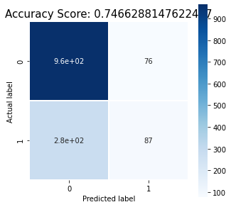

```python
cm = confusion_matrix(y_test, y_pred)
plt.figure(figsize=(5,5))
sns.heatmap(data=cm,linewidths=.5, annot=True,square = True,  cmap = 'Blues')
plt.ylabel('Actual label')
plt.xlabel('Predicted label')
all_sample_title = 'Accuracy Score: {0}'.format(clf.score(x_test, y_test))
plt.title(all_sample_title, size = 15)
```

```python
!pip install graphviz

!pip install pydotplus
```

```python
pip install.scikit-learn==0.20.3
```

```
ERROR: unknown command "install.scikit-learn==0.20.3"
```

```python
from sklearn.tree import export_graphviz
from sklearn.externals.six import StringIO
from IPython.display import Image
import pydotplus

dot_data = StringIO()
export_graphviz(clf, out_file=dot_data, filled=True, rounded=True, special_characters=True,feature_names = x_train,class_names=['Yes','No'])
graph = pydotplus.graph_from_dot_data(dot_data.getvalue())
graph.write_png('diabetes')
Image(graph.create_png())
```

[output not shown]

### i. Divide the dataset in 70:30 ratio

### ii. Build the model on train set and predict the values on test set

### iii. Build the confusion matrix and calculate the accuracy

```python
from sklearn.model_selection import train_test_split

X=data[['tenure']]  # Features
y=data['Churn']  # Labels


# Split dataset into training set and test set
X_train, X_test, y_train, y_test = train_test_split(X, y, test_size=0.3)
```

```python
#Import Random Forest Model
from sklearn.ensemble import RandomForestClassifier

#Create a Random Forest Classifier
clf1=RandomForestClassifier(n_estimators=10)

#Train the model using the training sets y_pred=clf.predict(X_test)
clf1.fit(X_train,y_train)

y_pred=clf.predict(X_test)

#Import scikit-learn metrics module for accuracy calculation
from sklearn import metrics

# Model Accuracy, how often is the classifier correct?
print("Accuracy:",metrics.accuracy_score(y_test, y_pred))
```

```
Accuracy: 0.7501183151916706
```

[figure not shown]

```python
cm = confusion_matrix(y_test, y_pred)
plt.figure(figsize=(5,5))
sns.heatmap(data=cm,linewidths=.5, annot=True,square = True,  cmap = 'Blues')
plt.ylabel('Actual label')
plt.xlabel('Predicted label')
all_sample_title = 'Accuracy Score: {0}'.format(clf.score(X_test, y_test))
plt.title(all_sample_title, size = 15)
```

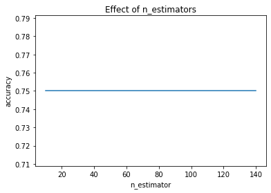

```python
# Try different numbers of n_estimators
estimators = np.arange(10, 150, 10)
accuracy = []

for n in estimators:
    clf1.set_params(n_estimators=n)
    clf1.fit(X_train, y_train)
    y_pred=clf.predict(X_test)
    accuracy.append(metrics.accuracy_score(y_test, y_pred))
plt.title("Effect of n_estimators")
plt.xlabel("n_estimator")
plt.ylabel("accuracy")
plt.plot(estimators, accuracy)
```